# Practical Machine Learning: Prediction Assignment

Chito Patiño

December 13, 2018

## Prediction Exercise

This project is intended to predict the manner in which people did their exercise using data from accelerometers on the belt, forearm, arm, and dumbell of 6 participants.

Below are information on the background and data source as noted in the course website.

### Background

Using devices such as Jawbone Up, Nike FuelBand, and Fitbit it is now possible to collect a large amount of data about personal activity relatively inexpensively. These type of devices are part of the quantified self movement – a group of enthusiasts who take measurements about themselves regularly to improve their health, to find patterns in their behavior, or because they are tech geeks. One thing that people regularly do is quantify how much of a particular activity they do, but they rarely quantify how well they do it. In this project, your goal will be to use data from accelerometers on the belt, forearm, arm, and dumbell of 6 participants. They were asked to perform barbell lifts correctly and incorrectly in 5 different ways.

### Data

The training data for this project are available here:

https://d396qusza40orc.cloudfront.net/predmachlearn/pml-training.csv

The test data are available here:

https://d396qusza40orc.cloudfront.net/predmachlearn/pml-testing.csv

The data for this project come from this source: http://web.archive.org/web/20161224072740/http:/groupware.les.inf.puc-rio.br/har.

## Methodology

### Load packages

We make use of the **caret**, **rattle**, and **rpart** packages for this project.

```r
library(caret)
library(rattle)
library(rpart)
```

### Loading the train data

We load the train dataset into the variable ‘TrainData’ and test data set into the variable ‘TestData’ from the online repository.

```r
TrainData <- read.csv(url("https://d396qusza40orc.cloudfront.net/predmachlearn/pml-training.csv"),
    header=T, sep=",", na.strings=c(""," ",NA))
dim(TrainData)
```

```
## [1] 19622   160
```

```r
TestData <- read.csv(url("https://d396qusza40orc.cloudfront.net/predmachlearn/pml-testing.csv"),
    header=T, sep=",", na.strings=c(""," ",NA))
dim(TestData)
```

```
## [1]  20 160
```

### Preprocessing

We want to remove columns which have several NAs. We set the threshold at 90% of NA or blank values. We are able to clean and reduce the number of columns to 53. The code is given below.

```r
NAcols <- which(colSums(is.na(TrainData) |TrainData=="")>0.9*dim(TrainData)[1])
TrainNAClean <- TrainData[,-NAcols]
TrainNAClean <- TrainNAClean[,-c(1:7)]
dim(TrainNAClean)
```

```
## [1] 19622    53
```

### Partitioning

We partition the cleaned training data into **training** and **testing** at a ratio of 70:30 so we can test for accuracy of our model without dealing with the actual **test** dataset.

```r
set.seed(12345)
TrainPartition<-createDataPartition(TrainNAClean$classe, p=0.7, list=FALSE)
training<-TrainNAClean[TrainPartition, ]
testing<-TrainNAClean[-TrainPartition, ]
dim(training)
```

```
## [1] 13737    53
```

```r
dim(testing)
```

```
## [1] 5885   53
```

### Training

For this project, we explore three machine learning models i.e. **classification trees**, **random forests**, and **generalized boosted model (gbm)** to find the algorithm with the highest accuracy of prediction.

### Classification Tree

We train the classification tree model using our partitioned training data and then check for its accuracy when applied to our partitioned test data.

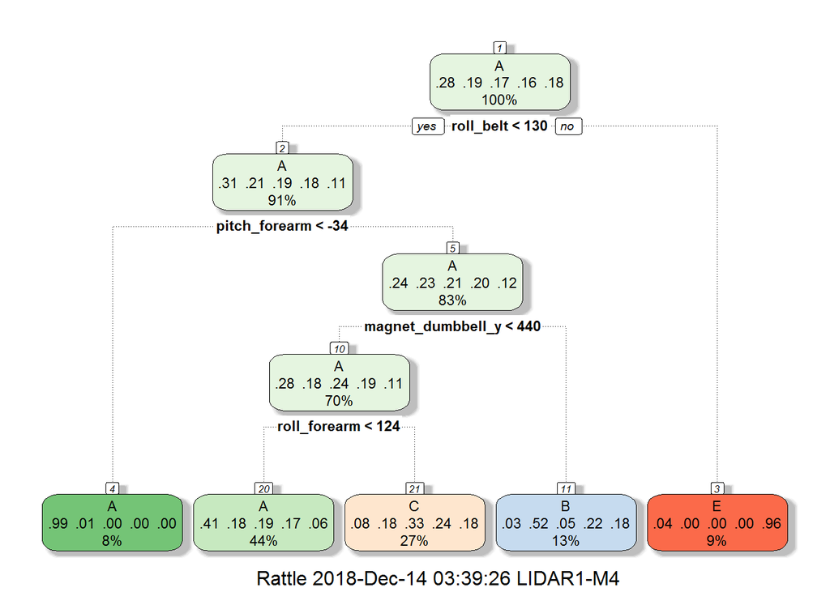

```r
CTree <- train(classe~., data=training, method="rpart",
        trControl=trainControl(method="cv", number=5))
fancyRpartPlot(CTree$finalModel)
```

```r
#predict using testing data
predTree <- predict(CTree, newdata=testing)
CMatrix <- confusionMatrix(predTree, testing$classe)
CMatrix
```

```
## Confusion Matrix and Statistics
##
##           Reference
## Prediction    A    B    C    D    E
##          A 1494  470  467  438  141
##          B   21  380   29  184  147
##          C  128  289  530  342  277
##          D    0    0    0    0    0
##          E   31    0    0    0  517
##
## Overall Statistics
##
##                Accuracy : 0.4963
##                  95% CI : (0.4835, 0.5092)
##     No Information Rate : 0.2845
##     P-Value [Acc > NIR] : < 2.2e-16
##
##                   Kappa : 0.3425
##  Mcnemar's Test P-Value : NA
##
## Statistics by Class:
##
##                      Class: A Class: B Class: C Class: D Class: E
## Sensitivity            0.8925  0.33363  0.51657   0.0000  0.47782
## Specificity            0.6400  0.91972  0.78679   1.0000  0.99355
## Pos Pred Value         0.4963  0.49934  0.33844      NaN  0.94343
## Neg Pred Value         0.9374  0.85187  0.88516   0.8362  0.89414
## Prevalence             0.2845  0.19354  0.17434   0.1638  0.18386
## Detection Rate         0.2539  0.06457  0.09006   0.0000  0.08785
## Detection Prevalence   0.5115  0.12931  0.26610   0.0000  0.09312
## Balanced Accuracy      0.7662  0.62667  0.65168   0.5000  0.73568
```

The accuracy of the model is found to be **49.63%**.

### Random Forest

We train now using random forest and then check for its accuracy when applied to our partitioned test data.

```r
RForest <- train(classe~., data=training, method="rf",
        trControl=trainControl(method="cv", number=5))
RForest
```

```
## Random Forest
##
## 13737 samples
##    52 predictor
##     5 classes: 'A', 'B', 'C', 'D', 'E'
##
## No pre-processing
## Resampling: Cross-Validated (5 fold)
## Summary of sample sizes: 10989, 10990, 10990, 10989, 10990
## Resampling results across tuning parameters:
##
##   mtry  Accuracy   Kappa
##    2    0.9917742  0.9895937
##   27    0.9909734  0.9885812
##   52    0.9860961  0.9824117
##
## Accuracy was used to select the optimal model using the largest value.
## The final value used for the model was mtry = 2.
```

```r
#predict using testing data
predRF<-predict(RForest, testing)
CMatrixRF <- confusionMatrix(predRF, testing$classe)
CMatrixRF
```

```
## Confusion Matrix and Statistics
##
##           Reference
## Prediction    A    B    C    D    E
##          A 1673   12    0    0    0
##          B    1 1121   18    0    0
##          C    0    6 1005   24    0
##          D    0    0    3  940    3
##          E    0    0    0    0 1079
##
## Overall Statistics
##
##                Accuracy : 0.9886
##                  95% CI : (0.9856, 0.9912)
##     No Information Rate : 0.2845
##     P-Value [Acc > NIR] : < 2.2e-16
##
##                   Kappa : 0.9856
##  Mcnemar's Test P-Value : NA
##
## Statistics by Class:
##
##                      Class: A Class: B Class: C Class: D Class: E
## Sensitivity            0.9994   0.9842   0.9795   0.9751   0.9972
## Specificity            0.9972   0.9960   0.9938   0.9988   1.0000
## Pos Pred Value         0.9929   0.9833   0.9710   0.9937   1.0000
## Neg Pred Value         0.9998   0.9962   0.9957   0.9951   0.9994
## Prevalence             0.2845   0.1935   0.1743   0.1638   0.1839
## Detection Rate         0.2843   0.1905   0.1708   0.1597   0.1833
## Detection Prevalence   0.2863   0.1937   0.1759   0.1607   0.1833
## Balanced Accuracy      0.9983   0.9901   0.9867   0.9869   0.9986
```

The accuracy of the model which used random forest is found to be **98.86%**.

### Gradient Boosting Method

Lastly, we train using gradient boosting method and then check for its accuracy when applied to our partitioned test data.

```r
GBMethod <- train(classe~., data=training, method="gbm", trControl=trainControl(method="cv", number=5), verbose=FALSE)
GBMethod
```

```
## Stochastic Gradient Boosting
##
## 13737 samples
##    52 predictor
##     5 classes: 'A', 'B', 'C', 'D', 'E'
##
## No pre-processing
## Resampling: Cross-Validated (5 fold)
## Summary of sample sizes: 10990, 10989, 10988, 10990, 10991
## Resampling results across tuning parameters:
##
##   interaction.depth  n.trees  Accuracy   Kappa
##   1                   50      0.7569334  0.6917125
##   1                  100      0.8241253  0.7773848
##   1                  150      0.8568123  0.8188032
##   2                   50      0.8566658  0.8183658
##   2                  100      0.9063854  0.8815112
##   2                  150      0.9323002  0.9143297
##   3                   50      0.8981594  0.8710576
##   3                  100      0.9419819  0.9265826
##   3                  150      0.9611996  0.9509080
##
## Tuning parameter 'shrinkage' was held constant at a value of 0.1
##
## Tuning parameter 'n.minobsinnode' was held constant at a value of 10
## Accuracy was used to select the optimal model using the largest value.
## The final values used for the model were n.trees = 150,
##  interaction.depth = 3, shrinkage = 0.1 and n.minobsinnode = 10.
```

```r
#predict using testing data
predGBM<-predict(GBMethod, testing)
CMatrixGBM <- confusionMatrix(predGBM, testing$classe)
CMatrixGBM
```

```
## Confusion Matrix and Statistics
##
##           Reference
## Prediction    A    B    C    D    E
##          A 1651   34    0    1    2
##          B   16 1073   33    3   21
##          C    4   32  975   36    9
##          D    3    0   17  915   18
##          E    0    0    1    9 1032
##
## Overall Statistics
##
##                Accuracy : 0.9594
##                  95% CI : (0.954, 0.9643)
##     No Information Rate : 0.2845
##     P-Value [Acc > NIR] : < 2.2e-16
##
##                   Kappa : 0.9486
##  Mcnemar's Test P-Value : 5.502e-08
##
## Statistics by Class:
##
##                      Class: A Class: B Class: C Class: D Class: E
## Sensitivity            0.9863   0.9421   0.9503   0.9492   0.9538
## Specificity            0.9912   0.9846   0.9833   0.9923   0.9979
## Pos Pred Value         0.9781   0.9363   0.9233   0.9601   0.9904
## Neg Pred Value         0.9945   0.9861   0.9894   0.9901   0.9897
## Prevalence             0.2845   0.1935   0.1743   0.1638   0.1839
## Detection Rate         0.2805   0.1823   0.1657   0.1555   0.1754
## Detection Prevalence   0.2868   0.1947   0.1794   0.1619   0.1771
## Balanced Accuracy      0.9887   0.9633   0.9668   0.9707   0.9759
```

The accuracy of the model using gbm is found to be **95.94%**.

### Conclusion

Based on the accuracy of the three models, **random forest** yielded the highest accuracy.

```r
#Clean test data
NACols <- which(colSums(is.na(TestData) |TestData=="")>0.9*dim(TestData)[1])
TestNAClean <- TestData[,-NACols]
TestNAClean <- TestNAClean[,-1]
#dim(TestDataClean)

#predict using testing data
prediction<-predict(RForest, TestNAClean)
```

We earlier used k-fold cross validation to get an estimate of the out of sample error with k=5.

### Out of sample error

```r
RForest$finalModel
```

```
##
## Call:
##  randomForest(x = x, y = y, mtry = param$mtry)
##                Type of random forest: classification
##                      Number of trees: 500
## No. of variables tried at each split: 2
##
##         OOB estimate of  error rate: 0.64%
## Confusion matrix:
##      A    B    C    D    E class.error
## A 3901    4    1    0    0 0.001280082
## B   17 2636    5    0    0 0.008276900
## C    0   23 2372    1    0 0.010016694
## D    0    0   32 2218    2 0.015097691
## E    0    0    0    3 2522 0.001188119
```